# Несбалансированные выборки

- Можно считать, что выборка несбалансирована, когда размеры классов отличаются более, чем в 10 раз
- Больший класс называют доминирующим, меньший класс называется минорным

[figure not shown]

Accuracy: $$ Accuracy = \frac{1}{l}\sum_{i=1}^l[y_i = a(x_i)]; $$

Precision (точность): $$ Precision = \frac{TP}{TP + FP}; $$

Recall (полнота): $$ Recall = \frac{TP}{TP + FN}; $$

где обозначения *TP*, *FP*, *FN* и *TN* — элементы матрицы ошибок:

|  | y = 1 | y = 0 |
| --- | --- | --- |
| a(x) = 1 | TP | FP (type I error, "ложная тревога") |
| a(x) = 0 | FN (type II error, "пропуск цели") | TN |

$f_1$-score: $$ f_1score = 2\cdot\frac{Precision \cdot Recall}{Precision + Recall} $$

[figure not shown]

См. [accuracy_score](http://scikit-learn.org/stable/modules/generated/sklearn.metrics.accuracy_score.html), [precision_score](http://scikit-learn.org/stable/modules/generated/sklearn.metrics.precision_score.html), [recall_score](http://scikit-learn.org/stable/modules/generated/sklearn.metrics.recall_score.html), [f1_score](http://scikit-learn.org/stable/modules/generated/sklearn.metrics.f1_score.html), [classification_report](http://scikit-learn.org/stable/modules/generated/sklearn.metrics.classification_report.html).

Напоминание по ROC-AUC:

- OX: $FPR = \frac{FP}{FP + TN}$
- OY: $TPR = \frac{TP}{TP + FN}$

и log-loss:

- $logloss = \sum_{i = 1}^{l}{y_i\log( p(x_i) ) + (1 - y_i)\log(1 - p(x_i))}$

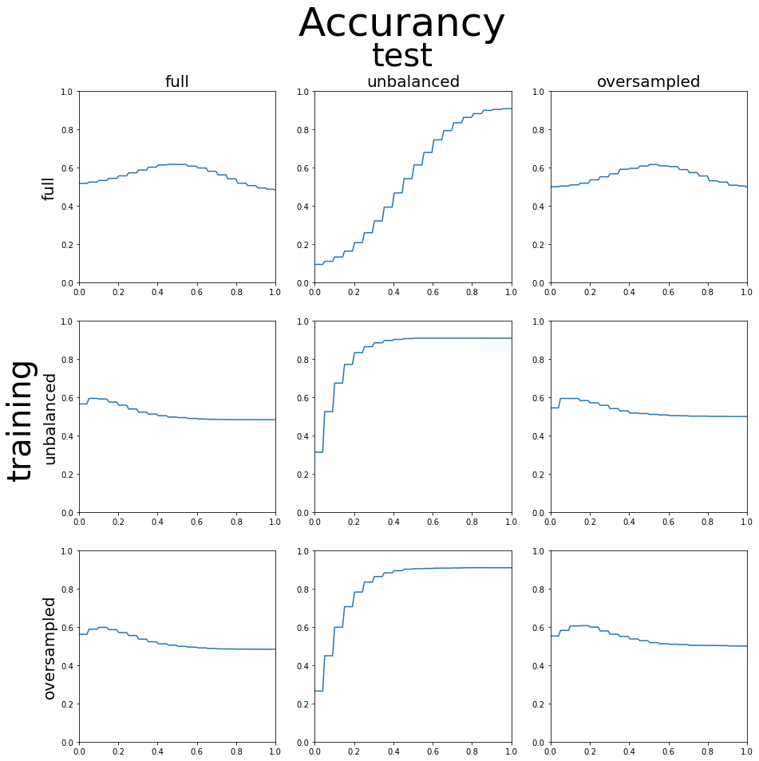

```python
plot_comparison(plot_accuracy)
```

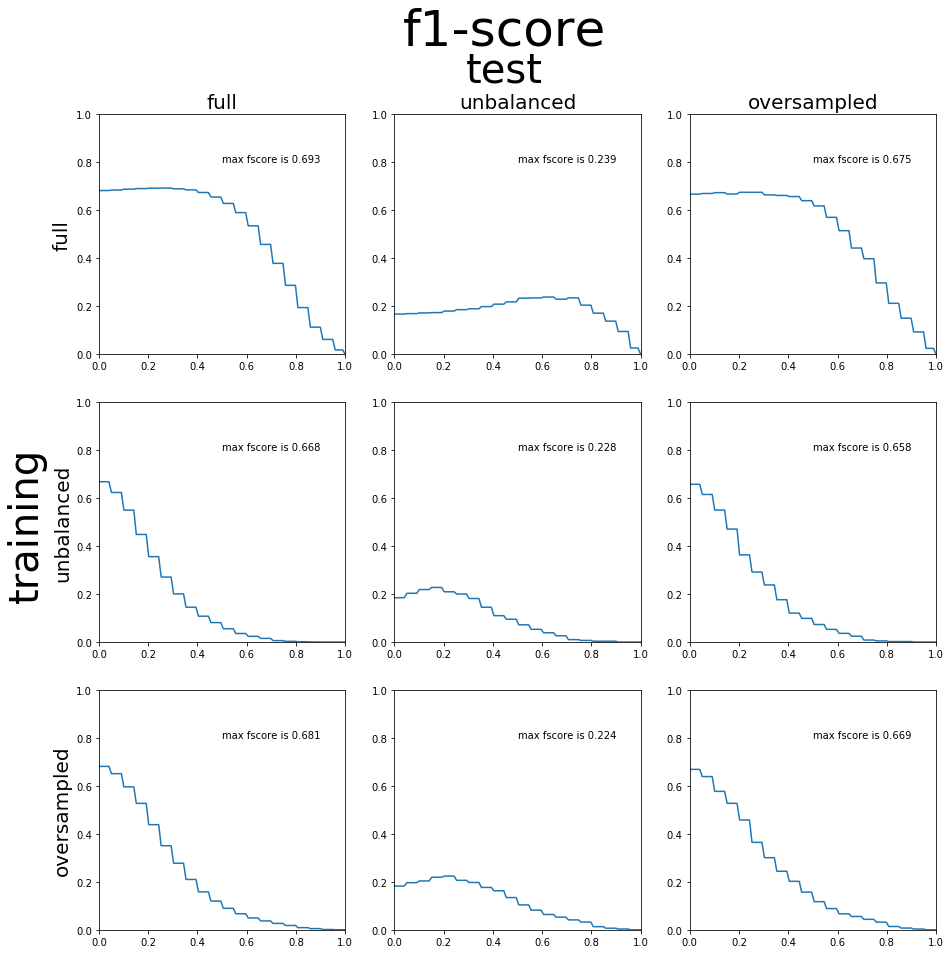

```python
plot_comparison(plot_fscore)
```

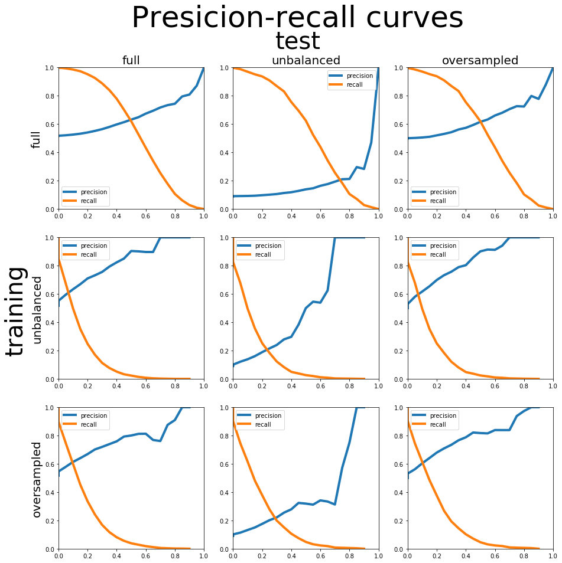

```python
plot_comparison(plot_precision_recall)
```

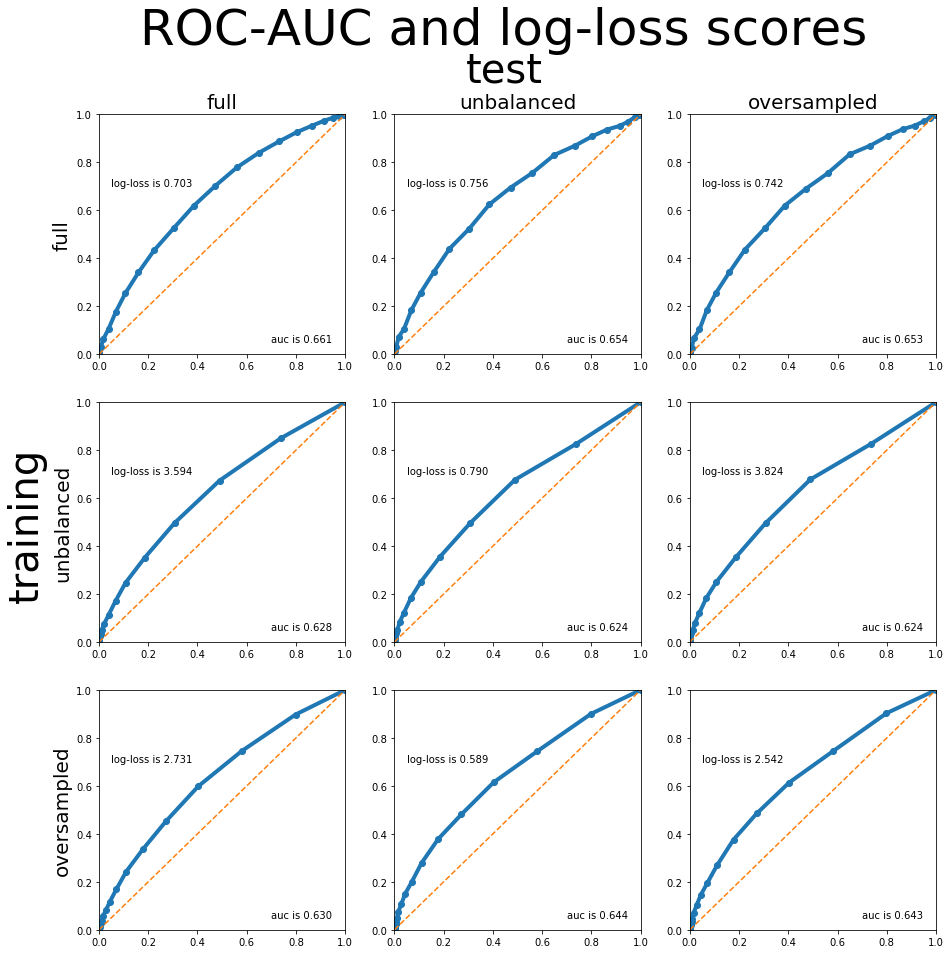

```python
plot_comparison(plot_roc_auc_logloss)
```

## Корректировка весов

- Большинство моделей в `sklearn` имеют параметр `class_weight`;
- Можно передавать словарь `{<label>: <weight>}` (по умолчанию каждый объект имеет вес 1)

## Модификация датасета

- Искуственное изменение пропорции меток в датасете
  - **Undersampling** — уменьшение размера доминирующего класса
  - **Oversampling** — увеличение размера минорного класса

[figure not shown]

- Для работы с несбалансированными выборками существует удобная библиотека [imbalanced-learn](http://contrib.scikit-learn.org/imbalanced-learn/index.html);
- Предоставляет большой выбор методов **undersampling**'a и **oversampling**'a;
- Имеет **API**, позволяющее встраиваться в **cross_val_predict** и **cross_val_score**;
- С установкой, возможно, придется повозиться.

### Undersampling

Уменьшение размера доминирующего класса

- Случайное выбрасывание объектов imblearn.under_sampling.RandomUnderSampler
- Замена доминирующих объектов на их кластера с помощью **KMeans** imblearn.under_sampling.ClusterCentroids

### Oversampling

Увеличение размера минорного класса

- Случайное повторение объектов из минорного класса imblearn.over_sampling.RandomOverSampler
- Генерация новых объектов с помощью линейной комбинации существующих [imblearn.under_sampling.SMOTE](http://contrib.scikit-learn.org/imbalanced-learn/generated/imblearn.over_sampling.SMOTE.html#imblearn.over_sampling.SMOTE)